# 05 - Drivers of spawning occupancy

Results 2.3: AR(1)-GAMM model set, collinearity, alternative drivers and robustness (Supplementary Tables S2-S5, Figs. S4-S5)

Sarah Ohayon, Jacob T. Dingwall, Amanda E. Bates

2026-10-01

The response is logit-transformed annual section occupancy. All models are generalized additive mixed models with a first-order autoregressive correlation structure across years, which absorbs the strong serial dependence of an annual series; predictors enter as penalised thin-plate splines.

Selective pressure on experienced spawners is indexed by the proportion of old fish (age ≥ 5) in the **dominant, most size-selective gear of each era** - reduction seines 1951-1965 and roe gillnets 1972-2024. No samples of either gear exist for the intervening years, which span the 1967 stock collapse and the 1968-1971 closure.

```r
annual <- read_csv(file.path(DERIVED, "annual_series.csv"), show_col_types = FALSE)

dm <- annual %>%
  filter(!is.na(occupancy), !is.na(prop_old_wt), !is.na(prop_old_n),
         !is.na(mean_SST), !is.na(ONI_ann), !is.na(mean_PDO)) %>%
  arrange(Year)

cat(sprintf("Model frame: n = %d years (%d-%d)\n", nrow(dm), min(dm$Year), max(dm$Year)))
```

```
## Model frame: n = 67 years (1951-2024)
```

```r
cat(sprintf("cor(prop_old_wt, prop_old_n) = %.4f\n", cor(dm$prop_old_wt, dm$prop_old_n)))
```

```
## cor(prop_old_wt, prop_old_n) = 0.9995
```

## 1 Supplementary Table S3 - collinearity screening

Screening is distinct from model selection: it establishes only that predictors entered into the *same* model are not redundant. The two derived removal metrics are algebraic functions of catch and the proportion of old fish, so they are collinear with their parents by construction and are never entered jointly with them; each is tested separately in Table S5.

```r
## value per tonne is not a candidate driver: it is treated as the market incentive upstream of
## selectivity (Results), not as a rival mechanism, and is shown descriptively in Fig. 1f
vif_set <- c("prop_old_wt","catch_total_t","SSB",
             "mean_SST","ONI_ann","mean_PDO")
vd <- dm %>% select(all_of(vif_set)) %>% drop_na()
Xv <- model.matrix(~ ., data = vd)[, -1]
vif <- sapply(seq_len(ncol(Xv)), function(i) 1/(1 - summary(lm(Xv[, i] ~ Xv[, -i]))$r.squared))

pretty_names <- c(prop_old_wt   = "Proportion of old fish",
                  catch_total_t = "Total catch",
                  SSB           = "Spawning stock biomass",
                  mean_SST      = "Mean SST",
                  ONI_ann       = "Oceanic Nino Index",
                  mean_PDO      = "Pacific Decadal Oscillation")

tabS3 <- tibble(Predictor = pretty_names[colnames(Xv)],
                VIF = round(vif, 2),
                `r with occupancy` = round(sapply(colnames(Xv),
                    function(v) cor(dm$occupancy, dm[[v]], use = "complete.obs")), 2)) %>%
  arrange(desc(VIF))
save_tab(tabS3, "TableS3_collinearity_VIF")
kable(tabS3, caption = sprintf(
  "Supplementary Table S3. Variance-inflation factors and correlation with occupancy (n = %d complete years). All VIF < %.1f.",
  nrow(vd), ceiling(10*max(vif))/10))
```

Supplementary Table S3. Variance-inflation factors and correlation with occupancy (n = 67 complete years). All VIF < 3.0.

| Predictor | VIF | r with occupancy |
| --- | --- | --- |
| Proportion of old fish | 2.91 | -0.73 |
| Total catch | 2.34 | 0.64 |
| Mean SST | 1.53 | -0.58 |
| Oceanic Nino Index | 1.43 | 0.08 |
| Pacific Decadal Oscillation | 1.33 | -0.02 |
| Spawning stock biomass | 1.27 | -0.28 |

## 2 Supplementary Table S2 - the driver-combination model set

The candidate set spans a null model, every subset of the three climate indices, the fishery predictor alone and additively with each climate subset, and each fishery × climate tensor interaction. Models are compared by AIC fitted with ML; adjusted R² and the AR(1) parameter are taken from the REML fit of the same structure.

```r
ctrl <- corAR1(form = ~ Year)

fit_one <- function(rhs, method, data = dm) {
  if (identical(trimws(rhs), "1")) {
    g <- tryCatch(gls(logit_occ ~ 1, data = data, correlation = ctrl, method = method),
                  error = function(e) NULL)
    if (is.null(g)) return(NULL)
    return(list(lme = g, gam = NULL))
  }
  tryCatch(gamm(as.formula(paste("logit_occ ~", rhs)), data = data,
                correlation = ctrl, method = method), error = function(e) NULL)
}
get_phi <- function(m) tryCatch(round(coef(m$lme$modelStruct$corStruct,
                                           unconstrained = FALSE), 3),
                                error = function(e) NA_real_)

model_defs <- tibble::tribble(
  ~name, ~group, ~rhs,
  "null","null","1",
  "SST","climate","s(mean_SST,k=5)",
  "ONI","climate","s(ONI_ann,k=4)",
  "PDO","climate","s(mean_PDO,k=5)",
  "SST+ONI","climate","s(mean_SST,k=5)+s(ONI_ann,k=4)",
  "SST+PDO","climate","s(mean_SST,k=5)+s(mean_PDO,k=5)",
  "ONI+PDO","climate","s(ONI_ann,k=4)+s(mean_PDO,k=5)",
  "SST+ONI+PDO","climate","s(mean_SST,k=5)+s(ONI_ann,k=4)+s(mean_PDO,k=5)",
  "OLD","fishing","s({OLD},k=5)",
  "OLD+SST","fish+clim","s({OLD},k=5)+s(mean_SST,k=5)",
  "OLD+ONI","fish+clim","s({OLD},k=5)+s(ONI_ann,k=4)",
  "OLD+PDO","fish+clim","s({OLD},k=5)+s(mean_PDO,k=5)",
  "OLD+SST+ONI","fish+clim","s({OLD},k=5)+s(mean_SST,k=5)+s(ONI_ann,k=4)",
  "OLD+SST+PDO","fish+clim","s({OLD},k=5)+s(mean_SST,k=5)+s(mean_PDO,k=5)",
  "OLD+ONI+PDO","fish+clim","s({OLD},k=5)+s(ONI_ann,k=4)+s(mean_PDO,k=5)",
  "OLD+SST+ONI+PDO","fish+clim","s({OLD},k=5)+s(mean_SST,k=5)+s(ONI_ann,k=4)+s(mean_PDO,k=5)",
  "OLD*SST","interaction","s({OLD},k=5)+s(mean_SST,k=5)+ti({OLD},mean_SST,k=c(4,4))",
  "OLD*ONI","interaction","s({OLD},k=5)+s(ONI_ann,k=4)+ti({OLD},ONI_ann,k=c(4,4))",
  "OLD*PDO","interaction","s({OLD},k=5)+s(mean_PDO,k=5)+ti({OLD},mean_PDO,k=c(4,4))")

run_model_set <- function(old_var, label = "prop_old", data = dm) {
  defs <- model_defs %>% mutate(rhs  = gsub("\\{OLD\\}", old_var, rhs),
                                name = gsub("OLD", label, name))
  map_dfr(seq_len(nrow(defs)), function(i) {
    ml <- fit_one(defs$rhs[i], "ML", data); re <- fit_one(defs$rhs[i], "REML", data)
    if (is.null(ml)) return(tibble(Model = defs$name[i], Class = defs$group[i],
                                   AIC = NA_real_, `adj. R2` = NA_real_, `AR(1) phi` = NA_real_))
    tibble(Model = defs$name[i], Class = defs$group[i], AIC = AIC(ml$lme),
           `adj. R2`   = if (is.null(re$gam)) NA_real_ else summary(re$gam)$r.sq,
           `AR(1) phi` = get_phi(re))
  }) %>%
    mutate(dAIC = round(AIC - min(AIC, na.rm = TRUE), 1),
           AIC  = round(AIC, 1), `adj. R2` = round(`adj. R2`, 3)) %>%
    arrange(dAIC) %>% relocate(dAIC, .after = AIC)
}

tabS2 <- run_model_set("prop_old_wt")
save_tab(tabS2, "TableS2_model_selection")
kable(tabS2, caption = sprintf(
  "Supplementary Table S2. Model selection for annual spawning occupancy. AR(1)-GAMMs of logit(occupancy), %d-%d (n = %d years), ordered by dAIC.",
  min(dm$Year), max(dm$Year), nrow(dm)))
```

Supplementary Table S2. Model selection for annual spawning occupancy. AR(1)-GAMMs of logit(occupancy), 1951-2024 (n = 67 years), ordered by dAIC.

| Model | Class | AIC | dAIC | adj. R2 | AR(1) phi |
| --- | --- | --- | --- | --- | --- |
| prop_old+SST | fish+clim | 109.5 | 0.0 | 0.606 | 0.414 |
| prop_old | fishing | 110.9 | 1.3 | 0.539 | 0.500 |
| prop_old+SST+ONI | fish+clim | 111.1 | 1.6 | 0.613 | 0.404 |
| prop_old+SST+PDO | fish+clim | 111.7 | 2.2 | 0.616 | 0.404 |
| prop_old*SST | interaction | 113.5 | 4.0 | 0.561 | 0.499 |
| prop_old+SST+ONI+PDO | fish+clim | 114.4 | 4.9 | 0.614 | 0.403 |
| prop_old+ONI | fish+clim | 114.5 | 5.0 | 0.532 | 0.499 |
| prop_old+PDO | fish+clim | 114.6 | 5.1 | 0.537 | 0.498 |
| prop_old+ONI+PDO | fish+clim | 118.4 | 8.9 | 0.528 | 0.497 |
| prop_old*ONI | interaction | 118.7 | 9.2 | 0.520 | 0.533 |
| prop_old*PDO | interaction | 119.9 | 10.4 | 0.527 | 0.510 |
| SST | climate | 121.2 | 11.7 | 0.234 | 0.680 |
| SST+ONI | climate | 122.2 | 12.7 | 0.295 | 0.642 |
| null | null | 122.5 | 12.9 | NA | 0.771 |
| SST+PDO | climate | 123.9 | 14.4 | 0.250 | 0.674 |
| SST+ONI+PDO | climate | 125.8 | 16.3 | 0.286 | 0.645 |
| ONI | climate | 126.1 | 16.6 | -0.010 | 0.766 |
| PDO | climate | 126.4 | 16.9 | -0.017 | 0.771 |
| ONI+PDO | climate | 130.1 | 20.6 | -0.026 | 0.765 |

## 3 Supplementary Table S4 - smooth-term statistics

```r
m_best <- fit_one("s(prop_old_wt,k=5)+s(mean_SST,k=5)", "REML")
m_full <- fit_one("s(prop_old_wt,k=5)+s(mean_SST,k=5)+s(ONI_ann,k=4)+s(mean_PDO,k=5)", "REML")
m_old  <- fit_one("s(prop_old_wt,k=5)", "REML")
m_sst  <- fit_one("s(mean_SST,k=5)", "REML")

term_lab <- c("s(prop_old_wt)" = "s(prop_old)", "s(mean_SST)" = "s(SST)",
              "s(ONI_ann)" = "s(ONI)", "s(mean_PDO)" = "s(PDO)")

smooth_rows <- function(m, model_label) {
  st <- summary(m$gam)$s.table
  tibble(Model = model_label,
         Term  = term_lab[rownames(st)],
         edf   = round(st[, "edf"], 2),
         F     = round(st[, "F"], 2),
         P     = signif(st[, "p-value"], 3))
}

tabS4 <- bind_rows(
  smooth_rows(m_best, "Best-supported: prop_old + SST"),
  smooth_rows(m_full, "Full additive: prop_old + SST + ONI + PDO"))
save_tab(tabS4, "TableS4_smooth_terms")
kable(tabS4, caption = "Supplementary Table S4. Smooth-term statistics for the best-supported and full additive models.")
```

Supplementary Table S4. Smooth-term statistics for the best-supported and full additive models.

| Model | Term | edf | F | P |
| --- | --- | --- | --- | --- |
| Best-supported: prop_old + SST | s(prop_old) | 2.21 | 12.20 | 2.31e-05 |
| Best-supported: prop_old + SST | s(SST) | 1.64 | 4.64 | 4.71e-02 |
| Full additive: prop_old + SST + ONI + PDO | s(prop_old) | 2.12 | 11.37 | 4.95e-05 |
| Full additive: prop_old + SST + ONI + PDO | s(SST) | 1.66 | 6.38 | 1.66e-02 |
| Full additive: prop_old + SST + ONI + PDO | s(ONI) | 1.00 | 1.06 | 3.08e-01 |
| Full additive: prop_old + SST + ONI + PDO | s(PDO) | 1.00 | 0.69 | 4.08e-01 |

```r
cat(sprintf("\nprop_old alone : adj. R2 = %.3f | phi = %.3f\n",
            summary(m_old$gam)$r.sq, get_phi(m_old)))
```

```
##
## prop_old alone : adj. R2 = 0.539 | phi = 0.500
```

```r
cat(sprintf("SST alone      : adj. R2 = %.3f | phi = %.3f\n",
            summary(m_sst$gam)$r.sq, get_phi(m_sst)))
```

```
## SST alone      : adj. R2 = 0.234 | phi = 0.680
```

```r
cat(sprintf("prop_old + SST : adj. R2 = %.3f | phi = %.3f\n",
            summary(m_best$gam)$r.sq, get_phi(m_best)))
```

```
## prop_old + SST : adj. R2 = 0.606 | phi = 0.414
```

```r
cat(sprintf("Full additive  : adj. R2 = %.3f | phi = %.3f | dAIC vs best = %.1f\n",
            summary(m_full$gam)$r.sq, get_phi(m_full),
            tabS2$dAIC[tabS2$Model == "prop_old+SST+ONI+PDO"]))
```

```
## Full additive  : adj. R2 = 0.614 | phi = 0.403 | dAIC vs best = 4.9
```

```r
cat(sprintf("Interaction models: minimum dAIC = %.1f\n",
            min(tabS2$dAIC[tabS2$Class == "interaction"])))
```

```
## Interaction models: minimum dAIC = 4.0
```

## 4 Supplementary Table S5 - alternative drivers

Each alternative predictor is fitted alone, and then added to the best-supported model. If selectivity is the operative mechanism, the *amount* removed and the *stock size* should each be weak alone and add nothing alongside the proportion of old fish.

```r
alt_row <- function(var, label, data = dm) {
  ma  <- fit_one(sprintf("s(%s,k=5)", var), "REML", data)
  mad <- fit_one(sprintf("s(prop_old_wt,k=5)+s(mean_SST,k=5)+s(%s,k=5)", var), "REML", data)
  sa  <- summary(ma$gam)$s.table
  sd_ <- summary(mad$gam)$s.table
  tibble(Predictor = label,
         `adj. R2 (alone)` = round(summary(ma$gam)$r.sq, 3),
         `F (alone)` = round(sa[paste0("s(",var,")"), "F"], 2),
         `P (alone)` = signif(sa[paste0("s(",var,")"), "p-value"], 3),
         `phi (alone)` = get_phi(ma),
         `F (added)` = round(sd_[paste0("s(",var,")"), "F"], 2),
         `P (added)` = signif(sd_[paste0("s(",var,")"), "p-value"], 3),
         `adj. R2 (model)` = round(summary(mad$gam)$r.sq, 3),
         `phi (model)` = get_phi(mad))
}

tabS5 <- bind_rows(
  alt_row("catch_total_t",    "Total catch"),
  alt_row("old_removed_t",    "Tonnage of old fish removed"),
  alt_row("old_removed_frac", "Population fraction of old fish removed"),
  alt_row("SSB",              "Spawning stock biomass"))
save_tab(tabS5, "TableS5_alternative_drivers")
kable(tabS5, caption = sprintf(
  "Supplementary Table S5. Alternative drivers of spawning occupancy, each fitted alone and added to the best-supported model (prop_old + SST; adj. R2 = %.2f, phi = %.2f).",
  summary(m_best$gam)$r.sq, get_phi(m_best)))
```

Supplementary Table S5. Alternative drivers of spawning occupancy, each fitted alone and added to the best-supported model (prop_old + SST; adj. R2 = 0.61, phi = 0.41).

| Predictor | adj. R2 (alone) | F (alone) | P (alone) | phi (alone) | F (added) | P (added) | adj. R2 (model) | phi (model) |
| --- | --- | --- | --- | --- | --- | --- | --- | --- |
| Total catch | 0.327 | 6.23 | 1.41e-02 | 0.647 | 0.60 | 0.44200 | 0.601 | 0.414 |
| Tonnage of old fish removed | -0.032 | 2.07 | 1.55e-01 | 0.783 | 0.00 | 0.94600 | 0.599 | 0.416 |
| Population fraction of old fish removed | -0.036 | 8.87 | 2.84e-05 | 0.867 | 5.05 | 0.00996 | 0.556 | 0.611 |
| Spawning stock biomass | -0.391 | 5.89 | 1.43e-03 | 0.893 | 4.11 | 0.01220 | 0.495 | 0.674 |

```r
## Supplementary Table S7 (GAMM columns): the occupancy models refitted on each presence rule
## (series written by 01), joined to the break and decoupling columns written by 03.
occ_rules <- read_csv(file.path(DERIVED, "occupancy_rule_sensitivity.csv"), show_col_types = FALSE)
tabS7b <- occ_rules %>% group_by(rule) %>% group_modify(function(x, k) {
  dr <- dm %>% select(-occupancy, -logit_occ) %>%
    inner_join(x %>% select(Year, occupancy), by = "Year") %>%
    mutate(logit_occ = qlogis(pmin(pmax(occupancy, 0.001), 0.999)))
  mo <- fit_one("s(prop_old_wt,k=5)", "REML", dr)
  mb <- fit_one("s(prop_old_wt,k=5)+s(mean_SST,k=5)", "REML", dr)
  aic_ml <- function(rhs) AIC(fit_one(rhs, "ML", dr)$lme)
  a_old <- aic_ml("s(prop_old_wt,k=5)")
  so <- summary(mo$gam)$s.table; sb <- summary(mb$gam)$s.table
  tibble(`prop_old alone: F`       = round(so["s(prop_old_wt)", "F"], 2),
         `prop_old alone: P`       = signif(so["s(prop_old_wt)", "p-value"], 2),
         `prop_old alone: adj. R2` = round(summary(mo$gam)$r.sq, 2),
         `prop_old + SST: adj. R2` = round(summary(mb$gam)$r.sq, 2),
         `prop_old + SST: SST P`   = signif(sb["s(mean_SST)", "p-value"], 2),
         `dAIC, prop_old + SST vs prop_old alone` = round(aic_ml("s(prop_old_wt,k=5)+s(mean_SST,k=5)") - a_old, 1),
         `dAIC, null vs prop_old alone`           = round(aic_ml("1") - a_old, 1))
}) %>% ungroup()
tabS7 <- read_csv(file.path(TABS, "TableS7_occupancy_rule_part_decoupling.csv"), show_col_types = FALSE) %>%
  left_join(tabS7b, by = "rule") %>%
  rename(`Presence rule` = rule) %>%
  arrange(match(`Presence rule`, c("Surveyed spawn records (main analysis)",
                                   "Spawn biomass > 0 only", "All spawn records")))
save_tab(tabS7, "TableS7_occupancy_rule_sensitivity")
kable(tabS7, caption = "Supplementary Table S7. Sensitivity of the occupancy results to the rule for which spawn records count as presence.")
```

Supplementary Table S7. Sensitivity of the occupancy results to the rule for which spawn records count as presence.

| Presence rule | Sections | supF | Break (95% CI) | Occupancy pre (%) | Occupancy post (%) | Occupancy post, matched SSB (%) | SSB P | Phase P | prop_old alone: F | prop_old alone: P | prop_old alone: adj. R2 | prop_old + SST: adj. R2 | prop_old + SST: SST P | dAIC, prop_old + SST vs prop_old alone | dAIC, null vs prop_old alone |
| --- | --- | --- | --- | --- | --- | --- | --- | --- | --- | --- | --- | --- | --- | --- | --- |
| Surveyed spawn records (main analysis) | 19 | 187 | after 1978 (1977-1980) | 66 | 33 | 33 | 0.32 | 0 | 13.82 | 6.6e-06 | 0.54 | 0.61 | 0.047 | -1.3 | 11.6 |
| Spawn biomass > 0 only | 18 | 208 | after 1982 (1981-1984) | 68 | 34 | 33 | 0.40 | 0 | 13.55 | 7.4e-06 | 0.53 | 0.61 | 0.020 | -3.0 | 11.4 |
| All spawn records | 19 | 117 | after 1977 (1975-1979) | 66 | 39 | 38 | 0.68 | 0 | 12.95 | 1.5e-05 | 0.47 | 0.50 | 0.280 | 2.0 | 11.3 |

## 5 Supplementary Fig. S4 - robustness of the selectivity result

Four independent ways of getting the answer wrong are tested: measuring selectivity by count rather than weight; broadening the fishery from roe gillnets to the whole roe fishery and to all fisheries; varying the age threshold that defines an old fish from ≥ 4 to ≥ 7; and refitting within the surface-survey period alone, so that the relationship is assessed under a single, constant survey method.

```r
## rebuild the spliced selectivity index at several age thresholds
bio_raw <- read_csv(F_BIO, show_col_types = FALSE, name_repair = "minimal", guess_max = 100000)
names(bio_raw) <- BIO_COLS
bio <- bio_raw %>%
  mutate(age = suppressWarnings(as.numeric(age)),
         weight_g = suppressWarnings(as.numeric(weight_g)),
         stat_area = suppressWarnings(as.numeric(stat_area)),
         Year = recode_two_digit_year(year)) %>%
  filter(stat_area %in% BIO_AREAS, !is.na(age), age >= 1, !is.na(weight_g))

prop_thr <- function(data, thr) {
  data %>% group_by(Year, season, sample_number) %>%
    summarise(n_fish = n(), po = sum(weight_g[age >= thr])/sum(weight_g), .groups = "drop") %>%
    filter(n_fish >= MIN_FISH) %>%
    group_by(Year) %>% summarise(prop = mean(po), .groups = "drop")
}

spliced <- function(thr, scope = c("gillnet","roe","all")) {
  scope <- match.arg(scope)
  red <- bio %>% filter(source == "Reduction Fishery")
  roe <- switch(scope,
    gillnet = bio %>% filter(source == "Roe Fishery", gear == "Gillnet"),
    roe     = bio %>% filter(source == "Roe Fishery"),
    all     = bio %>% filter(source != "Test Fishery"))
  bind_rows(prop_thr(red, thr) %>% filter(Year <= 1971),
            prop_thr(roe, thr) %>% filter(Year >= 1972)) %>% arrange(Year)
}

robust_fit <- function(series, label, variant) {
  d2 <- annual %>% select(Year, logit_occ, mean_SST) %>%
    inner_join(series %>% rename(prop = 2), by = "Year") %>%
    filter(!is.na(logit_occ), !is.na(prop), !is.na(mean_SST))
  m <- tryCatch(gamm(logit_occ ~ s(prop, k = 5) + s(mean_SST, k = 5), data = d2,
                     correlation = corAR1(form = ~ Year), method = "REML"),
                error = function(e) NULL)
  if (is.null(m)) return(NULL)
  st <- summary(m$gam)$s.table
  tibble(Variant = variant, Label = label, n = nrow(d2),
         edf = round(st["s(prop)","edf"], 2),
         F   = round(st["s(prop)","F"], 2),
         P   = st["s(prop)","p-value"],
         `adj. R2` = round(summary(m$gam)$r.sq, 3))
}

rob <- bind_rows(
  ## age thresholds, roe gillnet
  map_dfr(4:7, ~ robust_fit(spliced(.x, "gillnet"), sprintf("age \u2265 %d", .x), "Age threshold")),
  ## fishery breadth, age >= 5
  robust_fit(spliced(5, "gillnet"), "Roe gillnet",  "Fishery breadth"),
  robust_fit(spliced(5, "roe"),     "Full roe fishery", "Fishery breadth"),
  robust_fit(spliced(5, "all"),     "All fisheries",    "Fishery breadth"),
  ## weight vs count
  robust_fit(annual %>% select(Year, prop_old_wt), "By weight", "Selectivity metric"),
  robust_fit(annual %>% select(Year, prop_old_n),  "By count",  "Selectivity metric"))

## surface-survey period only
d_surf <- annual %>% filter(Year <= 1984)
m_surf <- gamm(logit_occ ~ s(prop_old_wt, k = 5) + s(mean_SST, k = 5),
               data = d_surf %>% filter(!is.na(prop_old_wt), !is.na(mean_SST)),
               correlation = corAR1(form = ~ Year), method = "REML")
st_surf <- summary(m_surf$gam)$s.table
rob <- bind_rows(rob, tibble(
  Variant = "Survey period", Label = "Surface surveys only (\u2264 1984)",
  n = sum(!is.na(d_surf$prop_old_wt) & !is.na(d_surf$mean_SST)),
  edf = round(st_surf["s(prop_old_wt)","edf"], 2),
  F   = round(st_surf["s(prop_old_wt)","F"], 2),
  P   = st_surf["s(prop_old_wt)","p-value"],
  `adj. R2` = round(summary(m_surf$gam)$r.sq, 3)))

save_tab(rob %>% mutate(P = signif(P, 3)), "robustness_selectivity")
kable(rob %>% mutate(P = signif(P, 3)),
      caption = "Robustness of the selectivity effect on spawning occupancy")
```

Robustness of the selectivity effect on spawning occupancy

| Variant | Label | n | edf | F | P | adj. R2 |
| --- | --- | --- | --- | --- | --- | --- |
| Age threshold | age ≥ 4 | 67 | 1.00 | 20.60 | 2.66e-05 | 0.581 |
| Age threshold | age ≥ 5 | 67 | 2.21 | 12.20 | 2.31e-05 | 0.606 |
| Age threshold | age ≥ 6 | 67 | 2.98 | 10.30 | 1.68e-05 | 0.622 |
| Age threshold | age ≥ 7 | 67 | 3.27 | 11.31 | 5.00e-06 | 0.637 |
| Fishery breadth | Roe gillnet | 67 | 2.21 | 12.20 | 2.31e-05 | 0.606 |
| Fishery breadth | Full roe fishery | 67 | 2.53 | 10.81 | 5.27e-05 | 0.606 |
| Fishery breadth | All fisheries | 68 | 1.49 | 8.03 | 1.65e-03 | 0.527 |
| Selectivity metric | By weight | 67 | 2.21 | 12.20 | 2.31e-05 | 0.606 |
| Selectivity metric | By count | 67 | 2.15 | 11.89 | 3.12e-05 | 0.600 |
| Survey period | Surface surveys only (≤ 1984) | 28 | 1.25 | 5.30 | 1.76e-02 | 0.319 |

## Subset refits: one survey era, and the pre-collapse era alone

Two questions the Results ask of this relationship: is it an artefact of the 1985 switch from surface to dive surveys, and is it merely a contrast between the pre- and post-collapse eras? Both are answered by refitting inside a single survey method and inside the pre-collapse era alone. Each subset is fitted twice: with the primary AR(1) GAMM used throughout the paper (as in Table S2 and Fig. S4) and with the AR(1) GLS slope used for the phase-controlled test, so that the manuscript and the supplement can quote the same model.

```r
sub <- annual %>%
  filter(!is.na(logit_occ), !is.na(prop_old_wt), !is.na(mean_SST)) %>%
  mutate(phase = factor(ifelse(Year < BREAK_YEAR, "Pre-collapse", "Post-collapse"),
                        levels = c("Pre-collapse", "Post-collapse")))

## GLS: a single linear slope, with collapse phase as a covariate where both phases are present
gls_slope <- function(dat) {
  form <- if (dplyr::n_distinct(dat$phase) > 1) logit_occ ~ prop_old_wt + phase
          else                                  logit_occ ~ prop_old_wt
  st <- summary(gls(form, data = dat, correlation = corAR1(form = ~ Year)))$tTable
  tibble(slope = round(st["prop_old_wt", "Value"], 2),
         SE    = round(st["prop_old_wt", "Std.Error"], 2),
         P     = st["prop_old_wt", "p-value"])
}

## GAMM: the primary model family (smooth of selectivity + smooth of SST)
gamm_smooth <- function(dat) {
  m  <- gamm(logit_occ ~ s(prop_old_wt, k = 5) + s(mean_SST, k = 5), data = dat,
             correlation = corAR1(form = ~ Year), method = "REML")
  st <- summary(m$gam)$s.table
  tibble(edf = round(st["s(prop_old_wt)", "edf"], 2),
         F   = round(st["s(prop_old_wt)", "F"], 2),
         P   = st["s(prop_old_wt)", "p-value"],
         r2  = round(summary(m$gam)$r.sq, 3))
}

subsets <- list("All years (1951-2024)"           = sub,
                "Surface-survey period (<= 1984)" = sub %>% filter(Year <= 1984),
                "Pre-collapse era (<= 1983)"      = sub %>% filter(Year <= 1983))

subset_refits <- bind_rows(lapply(names(subsets), function(nm) {
  d2 <- subsets[[nm]]; g <- gamm_smooth(d2); l <- gls_slope(d2)
  tibble(Subset = nm, n = nrow(d2),
         `GAMM edf` = g$edf, `GAMM F` = g$F, `GAMM P` = signif(g$P, 3),
         `GAMM adj. R2` = g$r2,
         `GLS slope` = l$slope, `GLS SE` = l$SE, `GLS P` = signif(l$P, 3))
}))

save_tab(subset_refits, "subset_refits")
kable(subset_refits,
      caption = "Selectivity effect refitted within a single survey era and within the pre-collapse era")
```

Selectivity effect refitted within a single survey era and within the pre-collapse era

[output not shown]

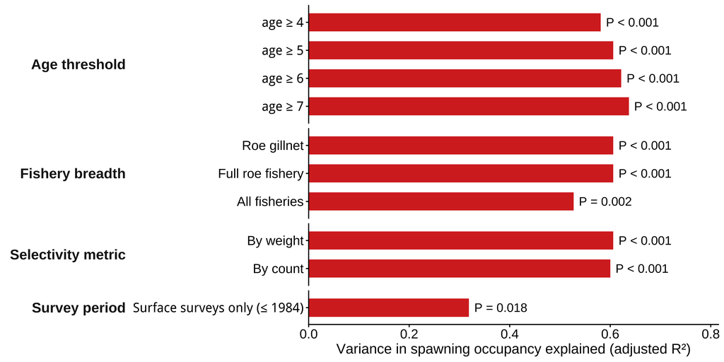

```r
figS4 <- rob %>%
  mutate(Variant = factor(Variant, levels = c("Age threshold","Fishery breadth",
                                              "Selectivity metric","Survey period")),
         Label = factor(Label, levels = rev(Label)),
         sig   = P < 0.05) %>%
  ggplot(aes(x = `adj. R2`, y = Label)) +
  geom_col(aes(fill = sig), width = 0.65) +
  geom_text(aes(label = sprintf("P %s", ifelse(P < 0.001, "< 0.001", sprintf("= %.3f", P)))),
            hjust = -0.1, size = 4.3) +
  facet_grid(Variant ~ ., scales = "free_y", space = "free_y", switch = "y") +
  scale_fill_manual(values = c(`TRUE` = col_old, `FALSE` = "grey70"), guide = "none") +
  scale_x_continuous(expand = expansion(mult = c(0, 0.28))) +
  ## no title: the figure is described by its legend in the Supplement
  labs(x = "Variance in spawning occupancy explained (adjusted R²)", y = NULL) +
  theme_herring(11) +
  theme(strip.placement = "outside",
        strip.text.y.left = element_text(angle = 0, hjust = 1, size = 14),
        axis.text  = element_text(size = 13, colour = "black"),
        axis.title = element_text(size = 14))
save_fig(figS4, "FigureS4_selectivity_robustness", width = 10, height = 5.5)
figS4
```

## 6 Supplementary Fig. S5 - partial effects of the four drivers

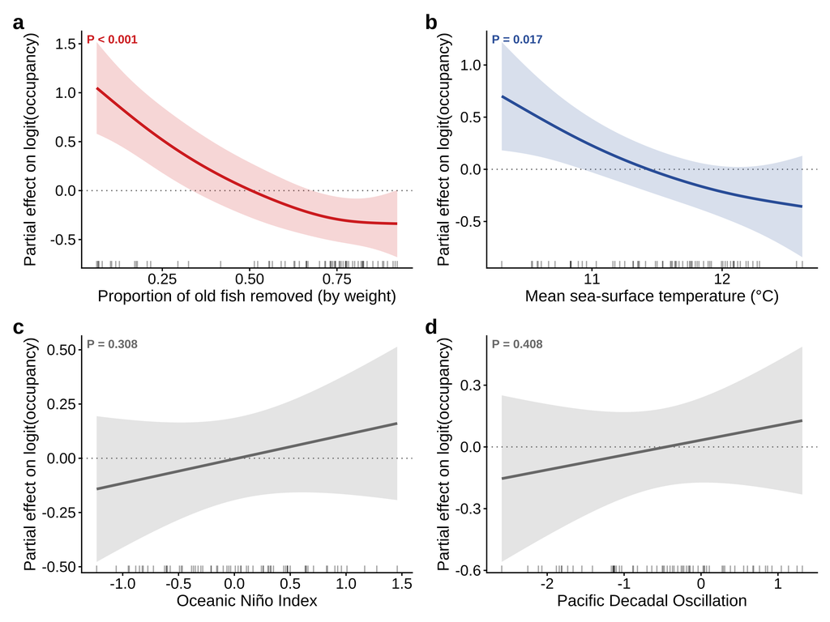

```r
st  <- summary(m_full$gam)$s.table
sm  <- smooth_estimates(m_full$gam) |> add_confint()
vars   <- c("prop_old_wt","mean_SST","ONI_ann","mean_PDO")
labs_v <- c(prop_old_wt = "Proportion of old fish removed (by weight)",
            mean_SST    = "Mean sea-surface temperature (°C)",
            ONI_ann     = "Oceanic Niño Index",
            mean_PDO    = "Pacific Decadal Oscillation")
cols_v <- c(prop_old_wt = col_old, mean_SST = col_sst,
            ONI_ann = "#7A7A7A", mean_PDO = "#7A7A7A")

mk <- function(v) {
  s <- sm |> filter(.smooth == paste0("s(", v, ")")) |> rename(x = all_of(v))
  r <- dm |> rename(x = all_of(v))
  p <- st[paste0("s(", v, ")"), "p-value"]
  ggplot(s, aes(x, .estimate)) +
    geom_hline(yintercept = 0, linetype = "dotted", colour = "grey50") +
    geom_ribbon(aes(ymin = .lower_ci, ymax = .upper_ci), alpha = 0.18, fill = cols_v[v]) +
    geom_line(colour = cols_v[v], linewidth = 1.1) +
    geom_rug(data = r, aes(x = x, y = NULL), inherit.aes = FALSE, alpha = 0.35, sides = "b") +
    annotate("text", x = -Inf, y = Inf, hjust = -0.1, vjust = 1.5, size = 3.6,
             fontface = "bold", colour = cols_v[v], label = sprintf("P %s", fmt_p(p))) +
    labs(x = labs_v[v], y = "Partial effect on logit(occupancy)") +
    theme_herring(11) +
    theme(axis.text  = element_text(size = 13, colour = "black"),
          axis.title = element_text(size = 14))
}

figS5 <- (mk("prop_old_wt") | mk("mean_SST")) / (mk("ONI_ann") | mk("mean_PDO")) +
  plot_annotation(tag_levels = "a") &
  theme(plot.tag = element_text(face = "bold", size = 18))
save_fig(figS5, "FigureS5_partial_effects", width = 10, height = 8)
figS5
```